신록예찬's 블로그

# (노트) 판다스 백엔드 플랏

Nov 28, 2021 • 신록예찬 • 50 min read

시각화

- imports
- theme
- line
  - 예제1 (matplotlib)
- bar, barh
  - 예제1 (matplotlib)
  - 예제1 (plotly)
- pie
  - 예제1 (matplotlib)
- boxplot
  - 예제1 (matplotlib)
  - 예제1 (plotly)
  - 예제2 (plotly)
- hist, kde, density
  - 예제1 (matplotlib)
  - 예제2 (plotly)
- area
  - 예제1 (matplotlib)
  - 예제1 (plotly)
  - 예제2 (matplotlib)
  - 예제2 (plotly)

### imports

```python
import numpy as np
import pandas as pd
import pandas.plotting
import matplotlib.pyplot as plt
import matplotlib
import warnings
from IPython.display import HTML
```

```python
from pandas_datareader import data as pdr
```

```python
def show(fig):
    return HTML(fig.to_html(include_plotlyjs='cdn', include_mathjax=False))
```

### theme

```python
import mplcyberpunk
plt.style.use("seaborn-dark")
#plt.style.use("cyberpunk")
matplotlib.pyplot.xkcd(scale=0, length=200)
```

### line

#### 예제1 (matplotlib)

```python
symbols = ['AMZN','AAPL', 'GOOG', 'FB', 'MSFT', 'NFLX', 'NVDA','TSLA']
start = '2020-01-01'
end = '2021-11-25'
df = pdr.get_data_yahoo(symbols, start, end)['Adj Close']
df
```

| Symbols Date | AMZN | AAPL | GOOG | FB | MSFT | NFLX | NVDA | TSLA |
| --- | --- | --- | --- | --- | --- | --- | --- | --- |
| 2019-12-31 | 1847.839966 | 72.337982 | 1337.020020 | 205.250000 | 154.749725 | 323.570007 | 58.676846 | 83.666000 |
| 2020-01-02 | 1898.010010 | 73.988472 | 1367.369995 | 209.779999 | 157.615112 | 329.809998 | 59.826447 | 86.052002 |
| 2020-01-03 | 1874.969971 | 73.269157 | 1360.660034 | 208.669998 | 155.652481 | 325.899994 | 58.868862 | 88.601997 |
| 2020-01-06 | 1902.880005 | 73.852974 | 1394.209961 | 212.600006 | 156.054871 | 335.829987 | 59.115734 | 90.307999 |
| 2020-01-07 | 1906.859985 | 73.505646 | 1393.339966 | 213.059998 | 154.632004 | 330.750000 | 59.831429 | 93.811996 |
| ... | ... | ... | ... | ... | ... | ... | ... | ... |
| 2021-11-18 | 3696.060059 | 157.869995 | 3014.179932 | 338.690002 | 341.269989 | 682.020020 | 316.711212 | 1096.380005 |
| 2021-11-19 | 3676.570068 | 160.550003 | 2999.050049 | 345.299988 | 343.109985 | 678.799988 | 329.809631 | 1137.060059 |
| 2021-11-22 | 3572.570068 | 161.020004 | 2941.570068 | 341.010010 | 339.829987 | 659.200012 | 319.520874 | 1156.869995 |
| 2021-11-23 | 3580.040039 | 161.410004 | 2935.139893 | 337.250000 | 337.679993 | 654.059998 | 317.421112 | 1109.030029 |
| 2021-11-24 | 3580.409912 | 161.940002 | 2934.350098 | 341.059998 | 337.910004 | 658.289978 | 326.699982 | 1116.000000 |

481 rows × 8 columns

```python
df.reset_index()
```

| Symbols | Date | AMZN | AAPL | GOOG | FB | MSFT | NFLX | NVDA | TSLA |
| --- | --- | --- | --- | --- | --- | --- | --- | --- | --- |
| 0 | 2019-12-31 | 1847.839966 | 72.337982 | 1337.020020 | 205.250000 | 154.749725 | 323.570007 | 58.676846 | 83.666000 |
| 1 | 2020-01-02 | 1898.010010 | 73.988472 | 1367.369995 | 209.779999 | 157.615112 | 329.809998 | 59.826447 | 86.052002 |
| 2 | 2020-01-03 | 1874.969971 | 73.269157 | 1360.660034 | 208.669998 | 155.652481 | 325.899994 | 58.868862 | 88.601997 |
| 3 | 2020-01-06 | 1902.880005 | 73.852974 | 1394.209961 | 212.600006 | 156.054871 | 335.829987 | 59.115734 | 90.307999 |
| 4 | 2020-01-07 | 1906.859985 | 73.505646 | 1393.339966 | 213.059998 | 154.632004 | 330.750000 | 59.831429 | 93.811996 |
| ... | ... | ... | ... | ... | ... | ... | ... | ... | ... |
| 476 | 2021-11-18 | 3696.060059 | 157.869995 | 3014.179932 | 338.690002 | 341.269989 | 682.020020 | 316.711212 | 1096.380005 |
| 477 | 2021-11-19 | 3676.570068 | 160.550003 | 2999.050049 | 345.299988 | 343.109985 | 678.799988 | 329.809631 | 1137.060059 |
| 478 | 2021-11-22 | 3572.570068 | 161.020004 | 2941.570068 | 341.010010 | 339.829987 | 659.200012 | 319.520874 | 1156.869995 |
| 479 | 2021-11-23 | 3580.040039 | 161.410004 | 2935.139893 | 337.250000 | 337.679993 | 654.059998 | 317.421112 | 1109.030029 |
| 480 | 2021-11-24 | 3580.409912 | 161.940002 | 2934.350098 | 341.059998 | 337.910004 | 658.289978 | 326.699982 | 1116.000000 |

481 rows × 9 columns

```python
df.stack().reset_index().rename(columns={0:'value'})
```

|  | Date | Symbols | value |
| --- | --- | --- | --- |
| 0 | 2019-12-31 | AMZN | 1847.839966 |
| 1 | 2019-12-31 | AAPL | 72.337982 |
| 2 | 2019-12-31 | GOOG | 1337.020020 |
| 3 | 2019-12-31 | FB | 205.250000 |
| 4 | 2019-12-31 | MSFT | 154.749725 |
| ... | ... | ... | ... |
| 3843 | 2021-11-24 | FB | 341.059998 |
| 3844 | 2021-11-24 | MSFT | 337.910004 |
| 3845 | 2021-11-24 | NFLX | 658.289978 |
| 3846 | 2021-11-24 | NVDA | 326.699982 |
| 3847 | 2021-11-24 | TSLA | 1116.000000 |

3848 rows × 3 columns

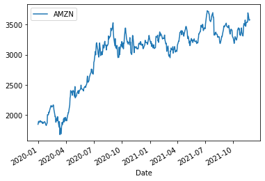

```python
df.plot.line(y='AMZN')
```

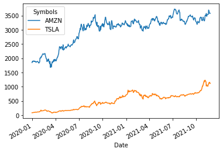

```python
df.plot.line(y=['AMZN','TSLA'])
```

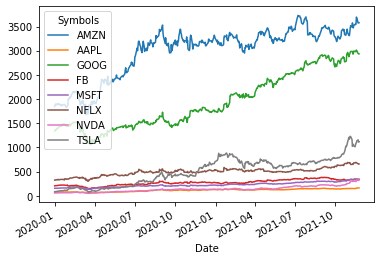

```python
df.plot.line()
```

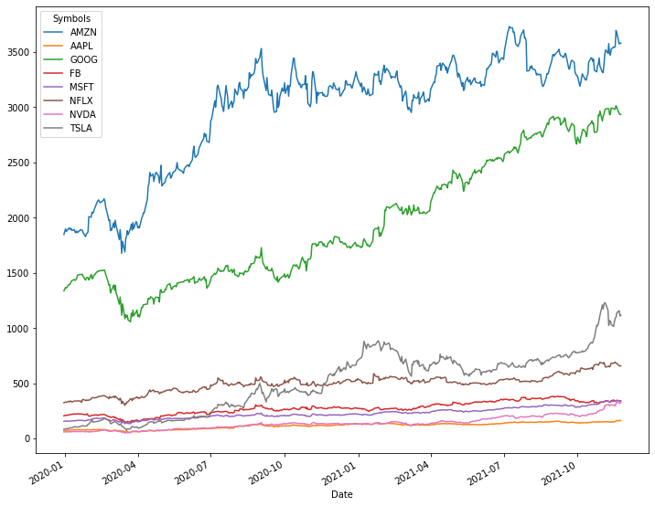

```python
df.plot.line(figsize=(12,10))
```

```
array([<AxesSubplot:xlabel='Date'>, <AxesSubplot:xlabel='Date'>,
       <AxesSubplot:xlabel='Date'>, <AxesSubplot:xlabel='Date'>,
       <AxesSubplot:xlabel='Date'>, <AxesSubplot:xlabel='Date'>,
       <AxesSubplot:xlabel='Date'>, <AxesSubplot:xlabel='Date'>],
      dtype=object)
```

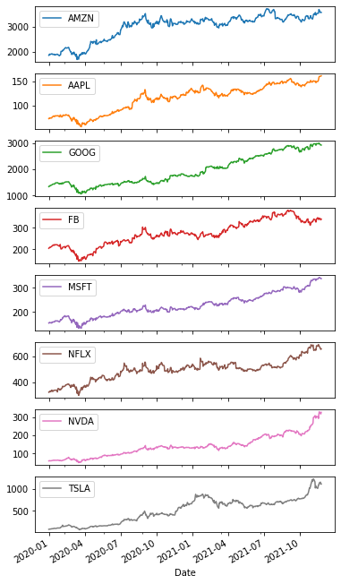

```python
df.plot.line(figsize=(6,12),subplots=True)
```

```
array([[<AxesSubplot:xlabel='Date'>, <AxesSubplot:xlabel='Date'>,
        <AxesSubplot:xlabel='Date'>, <AxesSubplot:xlabel='Date'>],
       [<AxesSubplot:xlabel='Date'>, <AxesSubplot:xlabel='Date'>,
        <AxesSubplot:xlabel='Date'>, <AxesSubplot:xlabel='Date'>]],
      dtype=object)
```

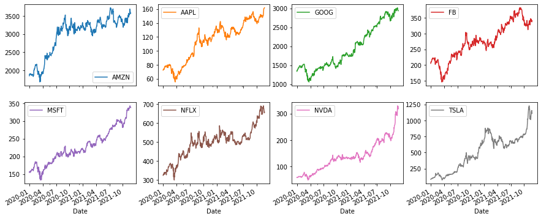

```python
df.plot.line(figsize=(15,6),subplots=True,layout=(2,4))
```

```
array([[<AxesSubplot:xlabel='Date'>, <AxesSubplot:xlabel='Date'>,
        <AxesSubplot:xlabel='Date'>, <AxesSubplot:xlabel='Date'>],
       [<AxesSubplot:xlabel='Date'>, <AxesSubplot:xlabel='Date'>,
        <AxesSubplot:xlabel='Date'>, <AxesSubplot:xlabel='Date'>]],
      dtype=object)
```

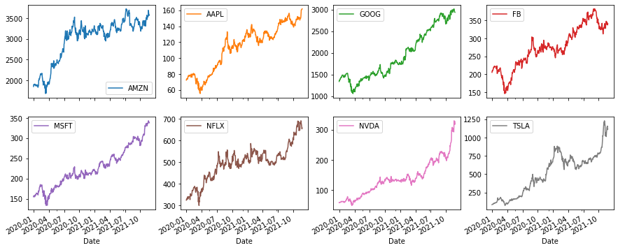

```python
df.plot.line(figsize=(15,6),subplots=True,layout=(2,4),fontsize=10)
```

```
array([[<AxesSubplot:xlabel='Date'>, <AxesSubplot:xlabel='Date'>,
        <AxesSubplot:xlabel='Date'>, <AxesSubplot:xlabel='Date'>],
       [<AxesSubplot:xlabel='Date'>, <AxesSubplot:xlabel='Date'>,
        <AxesSubplot:xlabel='Date'>, <AxesSubplot:xlabel='Date'>]],
      dtype=object)
```

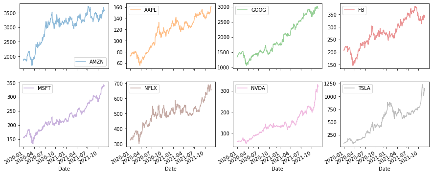

```python
df.plot.line(figsize=(15,6),subplots=True,layout=(2,4),fontsize=10,alpha=0.5)
```

```
array([[<AxesSubplot:xlabel='Date'>, <AxesSubplot:xlabel='Date'>,
        <AxesSubplot:xlabel='Date'>, <AxesSubplot:xlabel='Date'>],
       [<AxesSubplot:xlabel='Date'>, <AxesSubplot:xlabel='Date'>,
        <AxesSubplot:xlabel='Date'>, <AxesSubplot:xlabel='Date'>]],
      dtype=object)
```

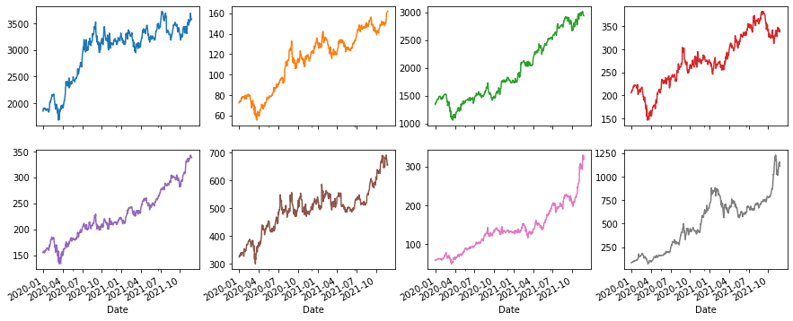

```python
df.plot.line(figsize=(15,6),subplots=True,layout=(2,4),legend=False)
```

### bar, barh

#### 예제1 (matplotlib)

```python
df = pd.read_csv('https://raw.githubusercontent.com/kalilurrahman/datasets/main/mobilephonemktshare2020.csv')
df
```

|  | Date | Samsung | Apple | Huawei | Xiaomi | Oppo | Mobicel | Motorola | LG | Others | Realme | Google | Nokia | Lenovo | OnePlus | Sony | Asus |
| --- | --- | --- | --- | --- | --- | --- | --- | --- | --- | --- | --- | --- | --- | --- | --- | --- | --- |
| 0 | 2019-10 | 31.49 | 22.09 | 10.02 | 7.79 | 4.10 | 3.15 | 2.41 | 2.40 | 9.51 | 0.54 | 2.35 | 0.95 | 0.96 | 0.70 | 0.84 | 0.74 |
| 1 | 2019-11 | 31.36 | 22.90 | 10.18 | 8.16 | 4.42 | 3.41 | 2.40 | 2.40 | 9.10 | 0.78 | 0.66 | 0.97 | 0.97 | 0.73 | 0.83 | 0.75 |
| 2 | 2019-12 | 31.37 | 24.79 | 9.95 | 7.73 | 4.23 | 3.19 | 2.50 | 2.54 | 8.13 | 0.84 | 0.75 | 0.90 | 0.87 | 0.74 | 0.77 | 0.70 |
| 3 | 2020-01 | 31.29 | 24.76 | 10.61 | 8.10 | 4.25 | 3.02 | 2.42 | 2.40 | 7.55 | 0.88 | 0.69 | 0.88 | 0.86 | 0.79 | 0.80 | 0.69 |
| 4 | 2020-02 | 30.91 | 25.89 | 10.98 | 7.80 | 4.31 | 2.89 | 2.36 | 2.34 | 7.06 | 0.89 | 0.70 | 0.81 | 0.77 | 0.78 | 0.80 | 0.69 |
| 5 | 2020-03 | 30.80 | 27.03 | 10.70 | 7.70 | 4.30 | 2.87 | 2.35 | 2.28 | 6.63 | 0.93 | 0.73 | 0.72 | 0.74 | 0.78 | 0.76 | 0.66 |
| 6 | 2020-04 | 30.41 | 28.79 | 10.28 | 7.60 | 4.20 | 2.75 | 2.51 | 2.28 | 5.84 | 0.90 | 0.75 | 0.69 | 0.71 | 0.80 | 0.76 | 0.70 |
| 7 | 2020-05 | 30.18 | 26.72 | 10.39 | 8.36 | 4.70 | 3.12 | 2.46 | 2.19 | 6.31 | 1.04 | 0.70 | 0.73 | 0.77 | 0.81 | 0.78 | 0.76 |
| 8 | 2020-06 | 31.06 | 25.26 | 10.69 | 8.55 | 4.65 | 3.18 | 2.57 | 2.11 | 6.39 | 1.04 | 0.68 | 0.74 | 0.75 | 0.77 | 0.78 | 0.75 |
| 9 | 2020-07 | 30.95 | 24.82 | 10.75 | 8.94 | 4.69 | 3.46 | 2.45 | 2.03 | 6.41 | 1.13 | 0.65 | 0.76 | 0.74 | 0.76 | 0.75 | 0.72 |
| 10 | 2020-08 | 31.04 | 25.15 | 10.73 | 8.90 | 4.69 | 3.38 | 2.39 | 1.96 | 6.31 | 1.18 | 0.63 | 0.74 | 0.72 | 0.75 | 0.73 | 0.70 |
| 11 | 2020-09 | 30.57 | 24.98 | 10.58 | 9.49 | 4.94 | 3.50 | 2.27 | 1.88 | 6.12 | 1.45 | 0.63 | 0.74 | 0.67 | 0.81 | 0.69 | 0.67 |
| 12 | 2020-10 | 30.25 | 26.53 | 10.44 | 9.67 | 4.83 | 2.54 | 2.21 | 1.79 | 6.04 | 1.55 | 0.63 | 0.69 | 0.65 | 0.85 | 0.67 | 0.64 |

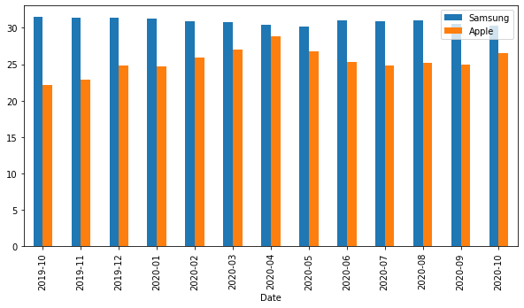

```python
df.plot.bar(x='Date', y=['Samsung','Apple'],figsize=(10,5))
```

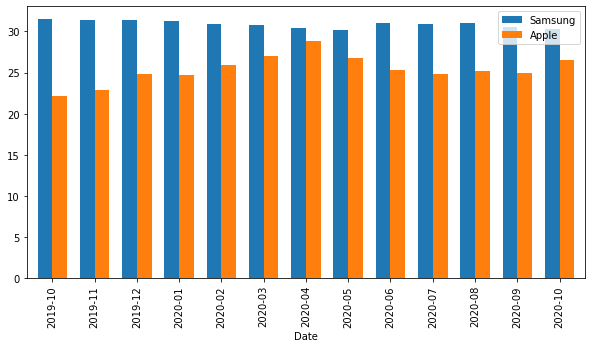

```python
df.plot.bar(x='Date', y=['Samsung','Apple'],figsize=(10,5),width=0.7)
```

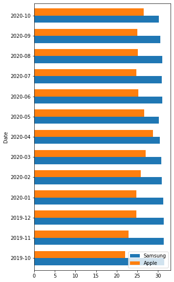

```python
df.plot.barh(x='Date', y=['Samsung','Apple'],figsize=(5,10),width=0.7)
```

```
array([[<AxesSubplot:title={'center':'Samsung'}, xlabel='Date'>,
        <AxesSubplot:title={'center':'Apple'}, xlabel='Date'>,
        <AxesSubplot:title={'center':'Huawei'}, xlabel='Date'>,
        <AxesSubplot:title={'center':'Xiaomi'}, xlabel='Date'>],
       [<AxesSubplot:title={'center':'Oppo'}, xlabel='Date'>,
        <AxesSubplot:title={'center':'Mobicel'}, xlabel='Date'>,
        <AxesSubplot:title={'center':'Motorola'}, xlabel='Date'>,
        <AxesSubplot:title={'center':'LG'}, xlabel='Date'>],
       [<AxesSubplot:title={'center':'Others'}, xlabel='Date'>,
        <AxesSubplot:title={'center':'Realme'}, xlabel='Date'>,
        <AxesSubplot:title={'center':'Google'}, xlabel='Date'>,
        <AxesSubplot:title={'center':'Nokia'}, xlabel='Date'>],
       [<AxesSubplot:title={'center':'Lenovo'}, xlabel='Date'>,
        <AxesSubplot:title={'center':'OnePlus'}, xlabel='Date'>,
        <AxesSubplot:title={'center':'Sony'}, xlabel='Date'>,
        <AxesSubplot:title={'center':'Asus'}, xlabel='Date'>]],
      dtype=object)
```

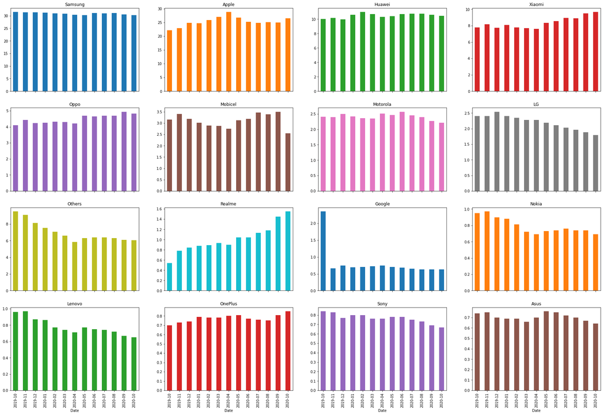

```python
df.plot.bar(x='Date',figsize=(30,20),subplots=True,layout=(4,4),legend=False)
```

- 이건 사실 라인플랏으로 그리는게 더 좋음

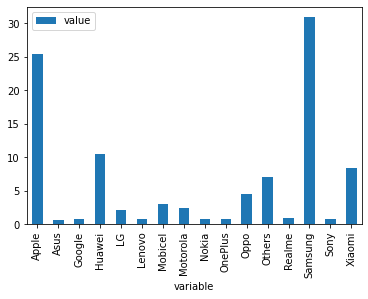

```python
df.melt(id_vars='Date').groupby('variable').agg(np.mean).plot.bar()
```

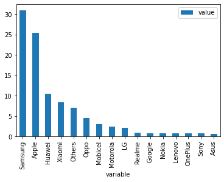

```python
df.melt(id_vars='Date').groupby('variable').agg(np.mean).sort_values('value',ascending=False).plot.bar()
```

#### 예제1 (plotly)

```python
fig = df.melt(id_vars='Date').groupby('variable').agg(np.mean).sort_values('value',ascending=False).plot.bar(backend='plotly')
show(fig)
```

[interactive chart not shown]

```python
fig = df.melt(id_vars='Date').plot.bar(x='Date',y='value',color='variable',backend='plotly')
show(fig)
```

[interactive chart not shown]

```python
fig = df.melt(id_vars='Date').query('variable=="Samsung" or variable=="Apple" or variable=="Huawei" or variable=="Xiaomi"').\
plot.bar(x='Date',y='value',color='variable',barmode='group',backend='plotly')
show(fig)
```

[interactive chart not shown]

```python
fig = df.melt(id_vars='Date').query('variable=="Samsung" or variable=="Apple" or variable=="Huawei" or variable=="Xiaomi"').\
plot.bar(x='Date',y='value',color='variable',barmode='group',backend='plotly',text='value')
show(fig)
```

[interactive chart not shown]

```python
fig = df.melt(id_vars='Date').query('variable=="Samsung" or variable=="Apple" or variable=="Huawei" or variable=="Xiaomi"').\
plot.bar(x='Date',y='value',color='variable',facet_col='variable',backend='plotly')
show(fig)
```

[interactive chart not shown]

```python
fig = df.melt(id_vars='Date').query('variable=="Samsung" or variable=="Apple" or variable=="Huawei" or variable=="Xiaomi"').\
plot.bar(x='value',y='Date',color='variable',facet_row='variable',backend='plotly',height=700)
show(fig)
```

[interactive chart not shown]

### pie

#### 예제1 (matplotlib)

```python
df = pd.read_csv('https://raw.githubusercontent.com/kalilurrahman/datasets/main/mobilephonemktshare2020.csv')
df
```

|  | Date | Samsung | Apple | Huawei | Xiaomi | Oppo | Mobicel | Motorola | LG | Others | Realme | Google | Nokia | Lenovo | OnePlus | Sony | Asus |
| --- | --- | --- | --- | --- | --- | --- | --- | --- | --- | --- | --- | --- | --- | --- | --- | --- | --- |
| 0 | 2019-10 | 31.49 | 22.09 | 10.02 | 7.79 | 4.10 | 3.15 | 2.41 | 2.40 | 9.51 | 0.54 | 2.35 | 0.95 | 0.96 | 0.70 | 0.84 | 0.74 |
| 1 | 2019-11 | 31.36 | 22.90 | 10.18 | 8.16 | 4.42 | 3.41 | 2.40 | 2.40 | 9.10 | 0.78 | 0.66 | 0.97 | 0.97 | 0.73 | 0.83 | 0.75 |
| 2 | 2019-12 | 31.37 | 24.79 | 9.95 | 7.73 | 4.23 | 3.19 | 2.50 | 2.54 | 8.13 | 0.84 | 0.75 | 0.90 | 0.87 | 0.74 | 0.77 | 0.70 |
| 3 | 2020-01 | 31.29 | 24.76 | 10.61 | 8.10 | 4.25 | 3.02 | 2.42 | 2.40 | 7.55 | 0.88 | 0.69 | 0.88 | 0.86 | 0.79 | 0.80 | 0.69 |
| 4 | 2020-02 | 30.91 | 25.89 | 10.98 | 7.80 | 4.31 | 2.89 | 2.36 | 2.34 | 7.06 | 0.89 | 0.70 | 0.81 | 0.77 | 0.78 | 0.80 | 0.69 |
| 5 | 2020-03 | 30.80 | 27.03 | 10.70 | 7.70 | 4.30 | 2.87 | 2.35 | 2.28 | 6.63 | 0.93 | 0.73 | 0.72 | 0.74 | 0.78 | 0.76 | 0.66 |
| 6 | 2020-04 | 30.41 | 28.79 | 10.28 | 7.60 | 4.20 | 2.75 | 2.51 | 2.28 | 5.84 | 0.90 | 0.75 | 0.69 | 0.71 | 0.80 | 0.76 | 0.70 |
| 7 | 2020-05 | 30.18 | 26.72 | 10.39 | 8.36 | 4.70 | 3.12 | 2.46 | 2.19 | 6.31 | 1.04 | 0.70 | 0.73 | 0.77 | 0.81 | 0.78 | 0.76 |
| 8 | 2020-06 | 31.06 | 25.26 | 10.69 | 8.55 | 4.65 | 3.18 | 2.57 | 2.11 | 6.39 | 1.04 | 0.68 | 0.74 | 0.75 | 0.77 | 0.78 | 0.75 |
| 9 | 2020-07 | 30.95 | 24.82 | 10.75 | 8.94 | 4.69 | 3.46 | 2.45 | 2.03 | 6.41 | 1.13 | 0.65 | 0.76 | 0.74 | 0.76 | 0.75 | 0.72 |
| 10 | 2020-08 | 31.04 | 25.15 | 10.73 | 8.90 | 4.69 | 3.38 | 2.39 | 1.96 | 6.31 | 1.18 | 0.63 | 0.74 | 0.72 | 0.75 | 0.73 | 0.70 |
| 11 | 2020-09 | 30.57 | 24.98 | 10.58 | 9.49 | 4.94 | 3.50 | 2.27 | 1.88 | 6.12 | 1.45 | 0.63 | 0.74 | 0.67 | 0.81 | 0.69 | 0.67 |
| 12 | 2020-10 | 30.25 | 26.53 | 10.44 | 9.67 | 4.83 | 2.54 | 2.21 | 1.79 | 6.04 | 1.55 | 0.63 | 0.69 | 0.65 | 0.85 | 0.67 | 0.64 |

`-` 하나의 파이차트를 만들어보자.

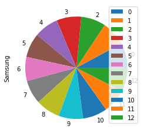

```python
df.plot.pie(y='Samsung')
```

- $0,1,2,3, \dots, 12$ 는 뭐지? $\to$ 인덱스
- 놀라울정도로 쓸모없는 차트.. 머 어쩌란 건지 설명자체가 불가능한 차트

`-` 0~12를 Date칼럼의 값들로 하는게 의미가 있다. $\to$ Date 칼럼을 인덱스로 하자!

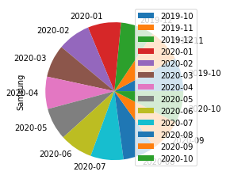

```python
df.set_index('Date').plot.pie(y='Samsung')
```

- 훨씬나음, 레전드를 제거해도 될듯

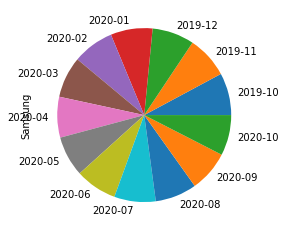

```python
df.set_index('Date').plot.pie(y='Samsung',legend=False)
```

`-` 여러개의 파이차트를 만들어보자. (별 생각없이!!)

```
array([[<AxesSubplot:ylabel='Samsung'>, <AxesSubplot:ylabel='Apple'>],
       [<AxesSubplot:ylabel='Huawei'>, <AxesSubplot:ylabel='Xiaomi'>]],
      dtype=object)
```

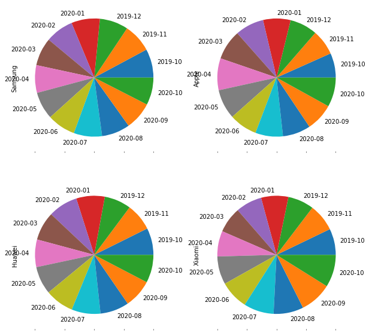

```python
df.set_index('Date').loc[:,['Samsung','Apple','Huawei','Xiaomi']].plot.pie(subplots=True,layout=(2,2),legend=False,figsize=(10,10))
```

`-` 성공했는데 왠지 쓸모없음

- 디자인: 날짜를 왜 색으로 표현해요? // 색으로 표현해야하는건 회사들 아닌가?

`-` 데이터의 구조자체가 틀려먹음

```python
df
```

|  | Date | Samsung | Apple | Huawei | Xiaomi | Oppo | Mobicel | Motorola | LG | Others | Realme | Google | Nokia | Lenovo | OnePlus | Sony | Asus |
| --- | --- | --- | --- | --- | --- | --- | --- | --- | --- | --- | --- | --- | --- | --- | --- | --- | --- |
| 0 | 2019-10 | 31.49 | 22.09 | 10.02 | 7.79 | 4.10 | 3.15 | 2.41 | 2.40 | 9.51 | 0.54 | 2.35 | 0.95 | 0.96 | 0.70 | 0.84 | 0.74 |
| 1 | 2019-11 | 31.36 | 22.90 | 10.18 | 8.16 | 4.42 | 3.41 | 2.40 | 2.40 | 9.10 | 0.78 | 0.66 | 0.97 | 0.97 | 0.73 | 0.83 | 0.75 |
| 2 | 2019-12 | 31.37 | 24.79 | 9.95 | 7.73 | 4.23 | 3.19 | 2.50 | 2.54 | 8.13 | 0.84 | 0.75 | 0.90 | 0.87 | 0.74 | 0.77 | 0.70 |
| 3 | 2020-01 | 31.29 | 24.76 | 10.61 | 8.10 | 4.25 | 3.02 | 2.42 | 2.40 | 7.55 | 0.88 | 0.69 | 0.88 | 0.86 | 0.79 | 0.80 | 0.69 |
| 4 | 2020-02 | 30.91 | 25.89 | 10.98 | 7.80 | 4.31 | 2.89 | 2.36 | 2.34 | 7.06 | 0.89 | 0.70 | 0.81 | 0.77 | 0.78 | 0.80 | 0.69 |
| 5 | 2020-03 | 30.80 | 27.03 | 10.70 | 7.70 | 4.30 | 2.87 | 2.35 | 2.28 | 6.63 | 0.93 | 0.73 | 0.72 | 0.74 | 0.78 | 0.76 | 0.66 |
| 6 | 2020-04 | 30.41 | 28.79 | 10.28 | 7.60 | 4.20 | 2.75 | 2.51 | 2.28 | 5.84 | 0.90 | 0.75 | 0.69 | 0.71 | 0.80 | 0.76 | 0.70 |
| 7 | 2020-05 | 30.18 | 26.72 | 10.39 | 8.36 | 4.70 | 3.12 | 2.46 | 2.19 | 6.31 | 1.04 | 0.70 | 0.73 | 0.77 | 0.81 | 0.78 | 0.76 |
| 8 | 2020-06 | 31.06 | 25.26 | 10.69 | 8.55 | 4.65 | 3.18 | 2.57 | 2.11 | 6.39 | 1.04 | 0.68 | 0.74 | 0.75 | 0.77 | 0.78 | 0.75 |
| 9 | 2020-07 | 30.95 | 24.82 | 10.75 | 8.94 | 4.69 | 3.46 | 2.45 | 2.03 | 6.41 | 1.13 | 0.65 | 0.76 | 0.74 | 0.76 | 0.75 | 0.72 |
| 10 | 2020-08 | 31.04 | 25.15 | 10.73 | 8.90 | 4.69 | 3.38 | 2.39 | 1.96 | 6.31 | 1.18 | 0.63 | 0.74 | 0.72 | 0.75 | 0.73 | 0.70 |
| 11 | 2020-09 | 30.57 | 24.98 | 10.58 | 9.49 | 4.94 | 3.50 | 2.27 | 1.88 | 6.12 | 1.45 | 0.63 | 0.74 | 0.67 | 0.81 | 0.69 | 0.67 |
| 12 | 2020-10 | 30.25 | 26.53 | 10.44 | 9.67 | 4.83 | 2.54 | 2.21 | 1.79 | 6.04 | 1.55 | 0.63 | 0.69 | 0.65 | 0.85 | 0.67 | 0.64 |

```python
df.T
```

|  | 0 | 1 | 2 | 3 | 4 | 5 | 6 | 7 | 8 | 9 | 10 | 11 | 12 |
| --- | --- | --- | --- | --- | --- | --- | --- | --- | --- | --- | --- | --- | --- |
| Date | 2019-10 | 2019-11 | 2019-12 | 2020-01 | 2020-02 | 2020-03 | 2020-04 | 2020-05 | 2020-06 | 2020-07 | 2020-08 | 2020-09 | 2020-10 |
| Samsung | 31.49 | 31.36 | 31.37 | 31.29 | 30.91 | 30.8 | 30.41 | 30.18 | 31.06 | 30.95 | 31.04 | 30.57 | 30.25 |
| Apple | 22.09 | 22.9 | 24.79 | 24.76 | 25.89 | 27.03 | 28.79 | 26.72 | 25.26 | 24.82 | 25.15 | 24.98 | 26.53 |
| Huawei | 10.02 | 10.18 | 9.95 | 10.61 | 10.98 | 10.7 | 10.28 | 10.39 | 10.69 | 10.75 | 10.73 | 10.58 | 10.44 |
| Xiaomi | 7.79 | 8.16 | 7.73 | 8.1 | 7.8 | 7.7 | 7.6 | 8.36 | 8.55 | 8.94 | 8.9 | 9.49 | 9.67 |
| Oppo | 4.1 | 4.42 | 4.23 | 4.25 | 4.31 | 4.3 | 4.2 | 4.7 | 4.65 | 4.69 | 4.69 | 4.94 | 4.83 |
| Mobicel | 3.15 | 3.41 | 3.19 | 3.02 | 2.89 | 2.87 | 2.75 | 3.12 | 3.18 | 3.46 | 3.38 | 3.5 | 2.54 |
| Motorola | 2.41 | 2.4 | 2.5 | 2.42 | 2.36 | 2.35 | 2.51 | 2.46 | 2.57 | 2.45 | 2.39 | 2.27 | 2.21 |
| LG | 2.4 | 2.4 | 2.54 | 2.4 | 2.34 | 2.28 | 2.28 | 2.19 | 2.11 | 2.03 | 1.96 | 1.88 | 1.79 |
| Others | 9.51 | 9.1 | 8.13 | 7.55 | 7.06 | 6.63 | 5.84 | 6.31 | 6.39 | 6.41 | 6.31 | 6.12 | 6.04 |
| Realme | 0.54 | 0.78 | 0.84 | 0.88 | 0.89 | 0.93 | 0.9 | 1.04 | 1.04 | 1.13 | 1.18 | 1.45 | 1.55 |
| Google | 2.35 | 0.66 | 0.75 | 0.69 | 0.7 | 0.73 | 0.75 | 0.7 | 0.68 | 0.65 | 0.63 | 0.63 | 0.63 |
| Nokia | 0.95 | 0.97 | 0.9 | 0.88 | 0.81 | 0.72 | 0.69 | 0.73 | 0.74 | 0.76 | 0.74 | 0.74 | 0.69 |
| Lenovo | 0.96 | 0.97 | 0.87 | 0.86 | 0.77 | 0.74 | 0.71 | 0.77 | 0.75 | 0.74 | 0.72 | 0.67 | 0.65 |
| OnePlus | 0.7 | 0.73 | 0.74 | 0.79 | 0.78 | 0.78 | 0.8 | 0.81 | 0.77 | 0.76 | 0.75 | 0.81 | 0.85 |
| Sony | 0.84 | 0.83 | 0.77 | 0.8 | 0.8 | 0.76 | 0.76 | 0.78 | 0.78 | 0.75 | 0.73 | 0.69 | 0.67 |
| Asus | 0.74 | 0.75 | 0.7 | 0.69 | 0.69 | 0.66 | 0.7 | 0.76 | 0.75 | 0.72 | 0.7 | 0.67 | 0.64 |

- 이런느낌이어야함.

`-` Date를 index로 선정하고 transpose하면 될것 같음

```python
df.set_index('Date').T
```

| Date | 2019-10 | 2019-11 | 2019-12 | 2020-01 | 2020-02 | 2020-03 | 2020-04 | 2020-05 | 2020-06 | 2020-07 | 2020-08 | 2020-09 | 2020-10 |
| --- | --- | --- | --- | --- | --- | --- | --- | --- | --- | --- | --- | --- | --- |
| Samsung | 31.49 | 31.36 | 31.37 | 31.29 | 30.91 | 30.80 | 30.41 | 30.18 | 31.06 | 30.95 | 31.04 | 30.57 | 30.25 |
| Apple | 22.09 | 22.90 | 24.79 | 24.76 | 25.89 | 27.03 | 28.79 | 26.72 | 25.26 | 24.82 | 25.15 | 24.98 | 26.53 |
| Huawei | 10.02 | 10.18 | 9.95 | 10.61 | 10.98 | 10.70 | 10.28 | 10.39 | 10.69 | 10.75 | 10.73 | 10.58 | 10.44 |
| Xiaomi | 7.79 | 8.16 | 7.73 | 8.10 | 7.80 | 7.70 | 7.60 | 8.36 | 8.55 | 8.94 | 8.90 | 9.49 | 9.67 |
| Oppo | 4.10 | 4.42 | 4.23 | 4.25 | 4.31 | 4.30 | 4.20 | 4.70 | 4.65 | 4.69 | 4.69 | 4.94 | 4.83 |
| Mobicel | 3.15 | 3.41 | 3.19 | 3.02 | 2.89 | 2.87 | 2.75 | 3.12 | 3.18 | 3.46 | 3.38 | 3.50 | 2.54 |
| Motorola | 2.41 | 2.40 | 2.50 | 2.42 | 2.36 | 2.35 | 2.51 | 2.46 | 2.57 | 2.45 | 2.39 | 2.27 | 2.21 |
| LG | 2.40 | 2.40 | 2.54 | 2.40 | 2.34 | 2.28 | 2.28 | 2.19 | 2.11 | 2.03 | 1.96 | 1.88 | 1.79 |
| Others | 9.51 | 9.10 | 8.13 | 7.55 | 7.06 | 6.63 | 5.84 | 6.31 | 6.39 | 6.41 | 6.31 | 6.12 | 6.04 |
| Realme | 0.54 | 0.78 | 0.84 | 0.88 | 0.89 | 0.93 | 0.90 | 1.04 | 1.04 | 1.13 | 1.18 | 1.45 | 1.55 |
| Google | 2.35 | 0.66 | 0.75 | 0.69 | 0.70 | 0.73 | 0.75 | 0.70 | 0.68 | 0.65 | 0.63 | 0.63 | 0.63 |
| Nokia | 0.95 | 0.97 | 0.90 | 0.88 | 0.81 | 0.72 | 0.69 | 0.73 | 0.74 | 0.76 | 0.74 | 0.74 | 0.69 |
| Lenovo | 0.96 | 0.97 | 0.87 | 0.86 | 0.77 | 0.74 | 0.71 | 0.77 | 0.75 | 0.74 | 0.72 | 0.67 | 0.65 |
| OnePlus | 0.70 | 0.73 | 0.74 | 0.79 | 0.78 | 0.78 | 0.80 | 0.81 | 0.77 | 0.76 | 0.75 | 0.81 | 0.85 |
| Sony | 0.84 | 0.83 | 0.77 | 0.80 | 0.80 | 0.76 | 0.76 | 0.78 | 0.78 | 0.75 | 0.73 | 0.69 | 0.67 |
| Asus | 0.74 | 0.75 | 0.70 | 0.69 | 0.69 | 0.66 | 0.70 | 0.76 | 0.75 | 0.72 | 0.70 | 0.67 | 0.64 |

```
array([[<AxesSubplot:ylabel='2019-10'>, <AxesSubplot:ylabel='2019-11'>,
        <AxesSubplot:ylabel='2019-12'>, <AxesSubplot:ylabel='2020-01'>],
       [<AxesSubplot:ylabel='2020-02'>, <AxesSubplot:ylabel='2020-03'>,
        <AxesSubplot:ylabel='2020-04'>, <AxesSubplot:ylabel='2020-05'>],
       [<AxesSubplot:ylabel='2020-06'>, <AxesSubplot:ylabel='2020-07'>,
        <AxesSubplot:ylabel='2020-08'>, <AxesSubplot:ylabel='2020-09'>],
       [<AxesSubplot:ylabel='2020-10'>, <AxesSubplot:>, <AxesSubplot:>,
        <AxesSubplot:>]], dtype=object)
```

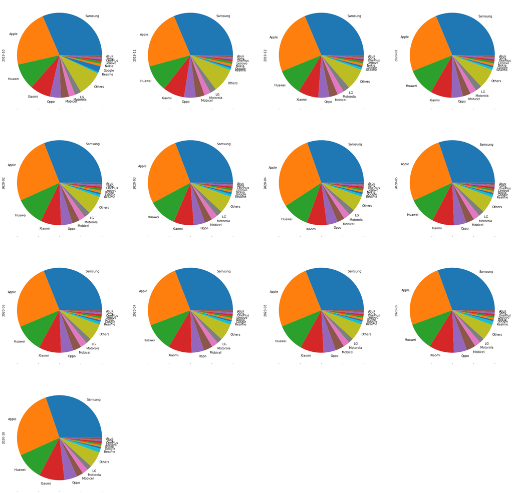

```python
df.set_index('Date').T.plot.pie(subplots=True,layout=(4,4),figsize=(30,30),legend=False)
```

`-` 아래도 가능함.

```
array([[<AxesSubplot:ylabel='2019-10'>, <AxesSubplot:ylabel='2019-11'>,
        <AxesSubplot:ylabel='2019-12'>, <AxesSubplot:ylabel='2020-01'>],
       [<AxesSubplot:ylabel='2020-02'>, <AxesSubplot:ylabel='2020-03'>,
        <AxesSubplot:ylabel='2020-04'>, <AxesSubplot:ylabel='2020-05'>],
       [<AxesSubplot:ylabel='2020-06'>, <AxesSubplot:ylabel='2020-07'>,
        <AxesSubplot:ylabel='2020-08'>, <AxesSubplot:ylabel='2020-09'>],
       [<AxesSubplot:ylabel='2020-10'>, <AxesSubplot:>, <AxesSubplot:>,
        <AxesSubplot:>]], dtype=object)
```

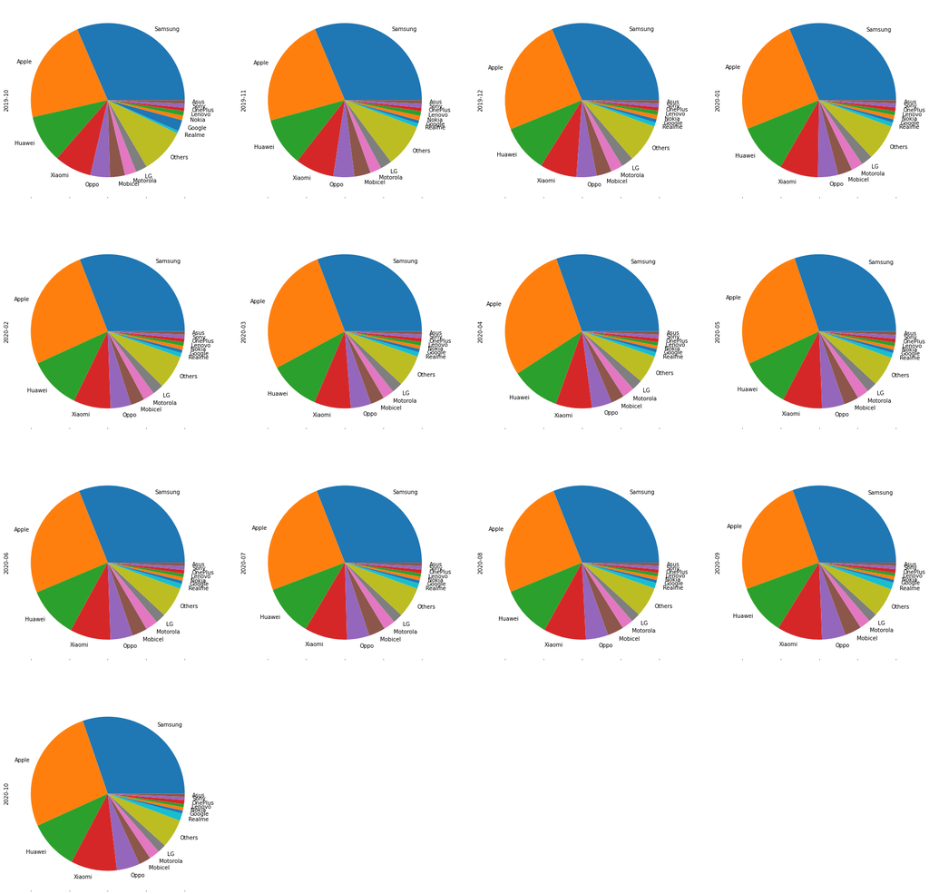

```python
df.set_index('Date').stack().swaplevel().unstack().plot.pie(subplots=True,figsize=(30,30),layout=(4,4),legend=False)
```

### boxplot

`-` plotly, matplotlib 백엔드 모두 지원

#### 예제1 (matplotlib)

```python
df = pd.read_csv('https://raw.githubusercontent.com/kalilurrahman/datasets/main/mobilephonemktshare2020.csv')
df
```

|  | Date | Samsung | Apple | Huawei | Xiaomi | Oppo | Mobicel | Motorola | LG | Others | Realme | Google | Nokia | Lenovo | OnePlus | Sony | Asus |
| --- | --- | --- | --- | --- | --- | --- | --- | --- | --- | --- | --- | --- | --- | --- | --- | --- | --- |
| 0 | 2019-10 | 31.49 | 22.09 | 10.02 | 7.79 | 4.10 | 3.15 | 2.41 | 2.40 | 9.51 | 0.54 | 2.35 | 0.95 | 0.96 | 0.70 | 0.84 | 0.74 |
| 1 | 2019-11 | 31.36 | 22.90 | 10.18 | 8.16 | 4.42 | 3.41 | 2.40 | 2.40 | 9.10 | 0.78 | 0.66 | 0.97 | 0.97 | 0.73 | 0.83 | 0.75 |
| 2 | 2019-12 | 31.37 | 24.79 | 9.95 | 7.73 | 4.23 | 3.19 | 2.50 | 2.54 | 8.13 | 0.84 | 0.75 | 0.90 | 0.87 | 0.74 | 0.77 | 0.70 |
| 3 | 2020-01 | 31.29 | 24.76 | 10.61 | 8.10 | 4.25 | 3.02 | 2.42 | 2.40 | 7.55 | 0.88 | 0.69 | 0.88 | 0.86 | 0.79 | 0.80 | 0.69 |
| 4 | 2020-02 | 30.91 | 25.89 | 10.98 | 7.80 | 4.31 | 2.89 | 2.36 | 2.34 | 7.06 | 0.89 | 0.70 | 0.81 | 0.77 | 0.78 | 0.80 | 0.69 |
| 5 | 2020-03 | 30.80 | 27.03 | 10.70 | 7.70 | 4.30 | 2.87 | 2.35 | 2.28 | 6.63 | 0.93 | 0.73 | 0.72 | 0.74 | 0.78 | 0.76 | 0.66 |
| 6 | 2020-04 | 30.41 | 28.79 | 10.28 | 7.60 | 4.20 | 2.75 | 2.51 | 2.28 | 5.84 | 0.90 | 0.75 | 0.69 | 0.71 | 0.80 | 0.76 | 0.70 |
| 7 | 2020-05 | 30.18 | 26.72 | 10.39 | 8.36 | 4.70 | 3.12 | 2.46 | 2.19 | 6.31 | 1.04 | 0.70 | 0.73 | 0.77 | 0.81 | 0.78 | 0.76 |
| 8 | 2020-06 | 31.06 | 25.26 | 10.69 | 8.55 | 4.65 | 3.18 | 2.57 | 2.11 | 6.39 | 1.04 | 0.68 | 0.74 | 0.75 | 0.77 | 0.78 | 0.75 |
| 9 | 2020-07 | 30.95 | 24.82 | 10.75 | 8.94 | 4.69 | 3.46 | 2.45 | 2.03 | 6.41 | 1.13 | 0.65 | 0.76 | 0.74 | 0.76 | 0.75 | 0.72 |
| 10 | 2020-08 | 31.04 | 25.15 | 10.73 | 8.90 | 4.69 | 3.38 | 2.39 | 1.96 | 6.31 | 1.18 | 0.63 | 0.74 | 0.72 | 0.75 | 0.73 | 0.70 |
| 11 | 2020-09 | 30.57 | 24.98 | 10.58 | 9.49 | 4.94 | 3.50 | 2.27 | 1.88 | 6.12 | 1.45 | 0.63 | 0.74 | 0.67 | 0.81 | 0.69 | 0.67 |
| 12 | 2020-10 | 30.25 | 26.53 | 10.44 | 9.67 | 4.83 | 2.54 | 2.21 | 1.79 | 6.04 | 1.55 | 0.63 | 0.69 | 0.65 | 0.85 | 0.67 | 0.64 |

`-` 시계열 자료의 차분

```python
df.set_index('Date').diff()
```

| Date | Samsung | Apple | Huawei | Xiaomi | Oppo | Mobicel | Motorola | LG | Others | Realme | Google | Nokia | Lenovo | OnePlus | Sony | Asus |
| --- | --- | --- | --- | --- | --- | --- | --- | --- | --- | --- | --- | --- | --- | --- | --- | --- |
| 2019-10 | NaN | NaN | NaN | NaN | NaN | NaN | NaN | NaN | NaN | NaN | NaN | NaN | NaN | NaN | NaN | NaN |
| 2019-11 | -0.13 | 0.81 | 0.16 | 0.37 | 0.32 | 0.26 | -0.01 | 0.00 | -0.41 | 0.24 | -1.69 | 0.02 | 0.01 | 0.03 | -0.01 | 0.01 |
| 2019-12 | 0.01 | 1.89 | -0.23 | -0.43 | -0.19 | -0.22 | 0.10 | 0.14 | -0.97 | 0.06 | 0.09 | -0.07 | -0.10 | 0.01 | -0.06 | -0.05 |
| 2020-01 | -0.08 | -0.03 | 0.66 | 0.37 | 0.02 | -0.17 | -0.08 | -0.14 | -0.58 | 0.04 | -0.06 | -0.02 | -0.01 | 0.05 | 0.03 | -0.01 |
| 2020-02 | -0.38 | 1.13 | 0.37 | -0.30 | 0.06 | -0.13 | -0.06 | -0.06 | -0.49 | 0.01 | 0.01 | -0.07 | -0.09 | -0.01 | 0.00 | 0.00 |
| 2020-03 | -0.11 | 1.14 | -0.28 | -0.10 | -0.01 | -0.02 | -0.01 | -0.06 | -0.43 | 0.04 | 0.03 | -0.09 | -0.03 | 0.00 | -0.04 | -0.03 |
| 2020-04 | -0.39 | 1.76 | -0.42 | -0.10 | -0.10 | -0.12 | 0.16 | 0.00 | -0.79 | -0.03 | 0.02 | -0.03 | -0.03 | 0.02 | 0.00 | 0.04 |
| 2020-05 | -0.23 | -2.07 | 0.11 | 0.76 | 0.50 | 0.37 | -0.05 | -0.09 | 0.47 | 0.14 | -0.05 | 0.04 | 0.06 | 0.01 | 0.02 | 0.06 |
| 2020-06 | 0.88 | -1.46 | 0.30 | 0.19 | -0.05 | 0.06 | 0.11 | -0.08 | 0.08 | 0.00 | -0.02 | 0.01 | -0.02 | -0.04 | 0.00 | -0.01 |
| 2020-07 | -0.11 | -0.44 | 0.06 | 0.39 | 0.04 | 0.28 | -0.12 | -0.08 | 0.02 | 0.09 | -0.03 | 0.02 | -0.01 | -0.01 | -0.03 | -0.03 |
| 2020-08 | 0.09 | 0.33 | -0.02 | -0.04 | 0.00 | -0.08 | -0.06 | -0.07 | -0.10 | 0.05 | -0.02 | -0.02 | -0.02 | -0.01 | -0.02 | -0.02 |
| 2020-09 | -0.47 | -0.17 | -0.15 | 0.59 | 0.25 | 0.12 | -0.12 | -0.08 | -0.19 | 0.27 | 0.00 | 0.00 | -0.05 | 0.06 | -0.04 | -0.03 |
| 2020-10 | -0.32 | 1.55 | -0.14 | 0.18 | -0.11 | -0.96 | -0.06 | -0.09 | -0.08 | 0.10 | 0.00 | -0.05 | -0.02 | 0.04 | -0.02 | -0.03 |

`-` 차분의 박스플랏

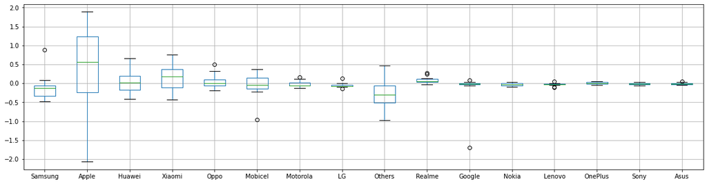

```python
df.set_index('Date').diff().dropna().boxplot(figsize=(20,5))
```

`-` 전월대비 몇프로 오르고 내렸는지 계산

```python
df.set_index('Date').pct_change()
```

| Date | Samsung | Apple | Huawei | Xiaomi | Oppo | Mobicel | Motorola | LG | Others | Realme | Google | Nokia | Lenovo | OnePlus | Sony | Asus |
| --- | --- | --- | --- | --- | --- | --- | --- | --- | --- | --- | --- | --- | --- | --- | --- | --- |
| 2019-10 | NaN | NaN | NaN | NaN | NaN | NaN | NaN | NaN | NaN | NaN | NaN | NaN | NaN | NaN | NaN | NaN |
| 2019-11 | -0.004128 | 0.036668 | 0.015968 | 0.047497 | 0.078049 | 0.082540 | -0.004149 | 0.000000 | -0.043113 | 0.444444 | -0.719149 | 0.021053 | 0.010417 | 0.042857 | -0.011905 | 0.013514 |
| 2019-12 | 0.000319 | 0.082533 | -0.022593 | -0.052696 | -0.042986 | -0.064516 | 0.041667 | 0.058333 | -0.106593 | 0.076923 | 0.136364 | -0.072165 | -0.103093 | 0.013699 | -0.072289 | -0.066667 |
| 2020-01 | -0.002550 | -0.001210 | 0.066332 | 0.047865 | 0.004728 | -0.053292 | -0.032000 | -0.055118 | -0.071341 | 0.047619 | -0.080000 | -0.022222 | -0.011494 | 0.067568 | 0.038961 | -0.014286 |
| 2020-02 | -0.012144 | 0.045638 | 0.034873 | -0.037037 | 0.014118 | -0.043046 | -0.024793 | -0.025000 | -0.064901 | 0.011364 | 0.014493 | -0.079545 | -0.104651 | -0.012658 | 0.000000 | 0.000000 |
| 2020-03 | -0.003559 | 0.044032 | -0.025501 | -0.012821 | -0.002320 | -0.006920 | -0.004237 | -0.025641 | -0.060907 | 0.044944 | 0.042857 | -0.111111 | -0.038961 | 0.000000 | -0.050000 | -0.043478 |
| 2020-04 | -0.012662 | 0.065113 | -0.039252 | -0.012987 | -0.023256 | -0.041812 | 0.068085 | 0.000000 | -0.119155 | -0.032258 | 0.027397 | -0.041667 | -0.040541 | 0.025641 | 0.000000 | 0.060606 |
| 2020-05 | -0.007563 | -0.071900 | 0.010700 | 0.100000 | 0.119048 | 0.134545 | -0.019920 | -0.039474 | 0.080479 | 0.155556 | -0.066667 | 0.057971 | 0.084507 | 0.012500 | 0.026316 | 0.085714 |
| 2020-06 | 0.029158 | -0.054641 | 0.028874 | 0.022727 | -0.010638 | 0.019231 | 0.044715 | -0.036530 | 0.012678 | 0.000000 | -0.028571 | 0.013699 | -0.025974 | -0.049383 | 0.000000 | -0.013158 |
| 2020-07 | -0.003542 | -0.017419 | 0.005613 | 0.045614 | 0.008602 | 0.088050 | -0.046693 | -0.037915 | 0.003130 | 0.086538 | -0.044118 | 0.027027 | -0.013333 | -0.012987 | -0.038462 | -0.040000 |
| 2020-08 | 0.002908 | 0.013296 | -0.001860 | -0.004474 | 0.000000 | -0.023121 | -0.024490 | -0.034483 | -0.015601 | 0.044248 | -0.030769 | -0.026316 | -0.027027 | -0.013158 | -0.026667 | -0.027778 |
| 2020-09 | -0.015142 | -0.006759 | -0.013979 | 0.066292 | 0.053305 | 0.035503 | -0.050209 | -0.040816 | -0.030111 | 0.228814 | 0.000000 | 0.000000 | -0.069444 | 0.080000 | -0.054795 | -0.042857 |
| 2020-10 | -0.010468 | 0.062050 | -0.013233 | 0.018967 | -0.022267 | -0.274286 | -0.026432 | -0.047872 | -0.013072 | 0.068966 | 0.000000 | -0.067568 | -0.029851 | 0.049383 | -0.028986 | -0.044776 |

`-` 박스플랏

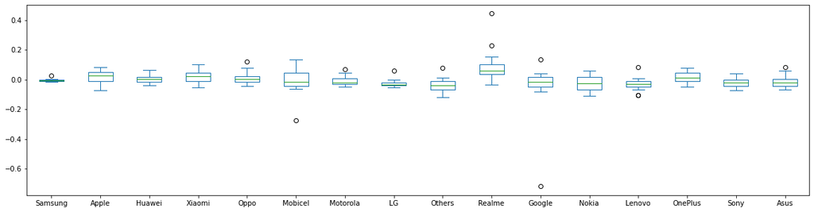

```python
df.set_index('Date').pct_change().dropna().plot.box(figsize=(20,5))
```

#### 예제1 (plotly)

`-` plotly로 tidy하지 않은 자료를 그릴수 있음

```python
df.set_index('Date').pct_change().dropna()
```

| Date | Samsung | Apple | Huawei | Xiaomi | Oppo | Mobicel | Motorola | LG | Others | Realme | Google | Nokia | Lenovo | OnePlus | Sony | Asus |
| --- | --- | --- | --- | --- | --- | --- | --- | --- | --- | --- | --- | --- | --- | --- | --- | --- |
| 2019-11 | -0.004128 | 0.036668 | 0.015968 | 0.047497 | 0.078049 | 0.082540 | -0.004149 | 0.000000 | -0.043113 | 0.444444 | -0.719149 | 0.021053 | 0.010417 | 0.042857 | -0.011905 | 0.013514 |
| 2019-12 | 0.000319 | 0.082533 | -0.022593 | -0.052696 | -0.042986 | -0.064516 | 0.041667 | 0.058333 | -0.106593 | 0.076923 | 0.136364 | -0.072165 | -0.103093 | 0.013699 | -0.072289 | -0.066667 |
| 2020-01 | -0.002550 | -0.001210 | 0.066332 | 0.047865 | 0.004728 | -0.053292 | -0.032000 | -0.055118 | -0.071341 | 0.047619 | -0.080000 | -0.022222 | -0.011494 | 0.067568 | 0.038961 | -0.014286 |
| 2020-02 | -0.012144 | 0.045638 | 0.034873 | -0.037037 | 0.014118 | -0.043046 | -0.024793 | -0.025000 | -0.064901 | 0.011364 | 0.014493 | -0.079545 | -0.104651 | -0.012658 | 0.000000 | 0.000000 |
| 2020-03 | -0.003559 | 0.044032 | -0.025501 | -0.012821 | -0.002320 | -0.006920 | -0.004237 | -0.025641 | -0.060907 | 0.044944 | 0.042857 | -0.111111 | -0.038961 | 0.000000 | -0.050000 | -0.043478 |
| 2020-04 | -0.012662 | 0.065113 | -0.039252 | -0.012987 | -0.023256 | -0.041812 | 0.068085 | 0.000000 | -0.119155 | -0.032258 | 0.027397 | -0.041667 | -0.040541 | 0.025641 | 0.000000 | 0.060606 |
| 2020-05 | -0.007563 | -0.071900 | 0.010700 | 0.100000 | 0.119048 | 0.134545 | -0.019920 | -0.039474 | 0.080479 | 0.155556 | -0.066667 | 0.057971 | 0.084507 | 0.012500 | 0.026316 | 0.085714 |
| 2020-06 | 0.029158 | -0.054641 | 0.028874 | 0.022727 | -0.010638 | 0.019231 | 0.044715 | -0.036530 | 0.012678 | 0.000000 | -0.028571 | 0.013699 | -0.025974 | -0.049383 | 0.000000 | -0.013158 |
| 2020-07 | -0.003542 | -0.017419 | 0.005613 | 0.045614 | 0.008602 | 0.088050 | -0.046693 | -0.037915 | 0.003130 | 0.086538 | -0.044118 | 0.027027 | -0.013333 | -0.012987 | -0.038462 | -0.040000 |
| 2020-08 | 0.002908 | 0.013296 | -0.001860 | -0.004474 | 0.000000 | -0.023121 | -0.024490 | -0.034483 | -0.015601 | 0.044248 | -0.030769 | -0.026316 | -0.027027 | -0.013158 | -0.026667 | -0.027778 |
| 2020-09 | -0.015142 | -0.006759 | -0.013979 | 0.066292 | 0.053305 | 0.035503 | -0.050209 | -0.040816 | -0.030111 | 0.228814 | 0.000000 | 0.000000 | -0.069444 | 0.080000 | -0.054795 | -0.042857 |
| 2020-10 | -0.010468 | 0.062050 | -0.013233 | 0.018967 | -0.022267 | -0.274286 | -0.026432 | -0.047872 | -0.013072 | 0.068966 | 0.000000 | -0.067568 | -0.029851 | 0.049383 | -0.028986 | -0.044776 |

```python
fig = df.set_index('Date').pct_change().dropna().plot.box(backend='plotly')
show(fig)
```

[interactive chart not shown]

- plotly가 약간 융통성있는 편임

`-` 회사를 색깔별로 구분하여 범주를 만들고 싶다면 여전히 tidydata를 활용해야함

```python
df.set_index('Date').pct_change().dropna().melt()
```

|  | variable | value |
| --- | --- | --- |
| 0 | Samsung | -0.004128 |
| 1 | Samsung | 0.000319 |
| 2 | Samsung | -0.002550 |
| 3 | Samsung | -0.012144 |
| 4 | Samsung | -0.003559 |
| ... | ... | ... |
| 187 | Asus | -0.013158 |
| 188 | Asus | -0.040000 |
| 189 | Asus | -0.027778 |
| 190 | Asus | -0.042857 |
| 191 | Asus | -0.044776 |

192 rows × 2 columns

```python
fig = df.set_index('Date').pct_change().dropna().melt().plot.box(x='variable',y='value',color='variable',backend='plotly')
show(fig)
```

[interactive chart not shown]

- 범주 만들면 머가 좋냐고요? 범주를 클릭해보세요!!

[output not shown]

[output cut: 42 more lines]

[output not shown]

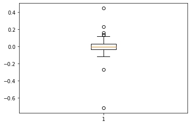

```python
df.set_index('Date').pct_change().dropna().melt().plot.box(x='variable',y='value',color='variable')
```

- 똑같은 코드가 matplotlib에서 돌아가는건 아님. matplotlib 백엔드는 타이디자료를 처리하지 않음

#### 예제2 (plotly)

`-` wide form 으로 정리가 불가능한 자료

```python
import plotly.express as px
df = px.data.tips()
df
```

|  | total_bill | tip | sex | smoker | day | time | size |
| --- | --- | --- | --- | --- | --- | --- | --- |
| 0 | 16.99 | 1.01 | Female | No | Sun | Dinner | 2 |
| 1 | 10.34 | 1.66 | Male | No | Sun | Dinner | 3 |
| 2 | 21.01 | 3.50 | Male | No | Sun | Dinner | 3 |
| 3 | 23.68 | 3.31 | Male | No | Sun | Dinner | 2 |
| 4 | 24.59 | 3.61 | Female | No | Sun | Dinner | 4 |
| ... | ... | ... | ... | ... | ... | ... | ... |
| 239 | 29.03 | 5.92 | Male | No | Sat | Dinner | 3 |
| 240 | 27.18 | 2.00 | Female | Yes | Sat | Dinner | 2 |
| 241 | 22.67 | 2.00 | Male | Yes | Sat | Dinner | 2 |
| 242 | 17.82 | 1.75 | Male | No | Sat | Dinner | 2 |
| 243 | 18.78 | 3.00 | Female | No | Thur | Dinner | 2 |

244 rows × 7 columns

- 성별, 식사금액, 금연여부, 요일, 점심/저녁에 따른 팁

`-` 팁은 대체로 어느정도씩 받는지?

```python
fig = df.plot.box(y='total_bill',backend='plotly',height=500,width=500)
show(fig)
```

[interactive chart not shown]

`-` 점심/저녁에 따라 팁의 분포가 다를까?

```python
fig = df.plot.box(x='time',y='total_bill',backend='plotly',height=500,width=500)
show(fig)
```

[interactive chart not shown]

- 저녁에 좀더 중앙값과 레인지가 커요

`-` 성별에 따라서도 팁을 주는것이 다를까?

```python
fig = df.plot.box(x='time',y='total_bill',color='sex',backend='plotly',height=500,width=500)
show(fig)
```

[interactive chart not shown]

`-` 분포를 같이보는 기법

```python
fig = df.plot.box(x='time',y='total_bill',color='sex',backend='plotly',height=500,width=500,points='all')
show(fig)
```

[interactive chart not shown]

- boxplot에서의 아웃라이어는 사라짐

`-` 요일에 따라서도 다를까?

```python
fig = df.plot.box(x='time',y='total_bill',color='sex',backend='plotly',height=500,width=1000,points='all',facet_col='day',facet_row='smoker')
show(fig)
```

[interactive chart not shown]

- tidydata로 한번만들어 두니까 너무너무 쉽게 생각하는대로 구현가능

`-` tidydata의 위력: 위와 같은 자료를 matplotlib backend로는 위의 그림을 그리는것 자체가! 불가능함

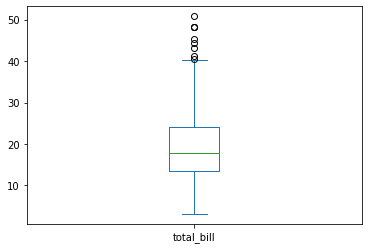

```python
df.plot.box(y='total_bill')
```

- `df.plot.box(x='time',y='total_bill',backend='plotly',height=500,width=500)` 와 같은 그림은 그릴 수 없다. (자료를 wide form으로 나타낼 수 없기 때문)

### hist, kde, density

#### 예제1 (matplotlib)

`-` 시뮬레이션 예제: 정규분포를 만들어서 제곱한뒤에 3개씩,4개씩,...,10개씩 더함 $\to$ 카이제곱분포

`-` 일단3개부터 시작해보자.

```python
X=np.random.normal(size=(1000,3),loc=0,scale=1)
X
```

```
array([[-1.63653253, -0.65625481,  1.11236588],
       [ 0.46460242,  0.11688344,  0.36095441],
       [ 1.48887296,  0.52955171,  0.30344685],
       ...,
       [ 0.97363802, -0.98445539, -0.81037974],
       [-0.62923164, -1.22343611,  1.38135751],
       [-0.71047452, -0.94117692, -0.05067565]])
```

```python
X**2
```

```
array([[2.67823871e+00, 4.30670377e-01, 1.23735786e+00],
       [2.15855411e-01, 1.36617384e-02, 1.30288089e-01],
       [2.21674270e+00, 2.80425012e-01, 9.20799912e-02],
       ...,
       [9.47971001e-01, 9.69152421e-01, 6.56715324e-01],
       [3.95932460e-01, 1.49679590e+00, 1.90814858e+00],
       [5.04774046e-01, 8.85814002e-01, 2.56802124e-03]])
```

```python
(X**2).sum()
```

```
3092.3384415386936
```

```python
8.87295628e-01+1.80485800e+00+2.54597648e+00
```

```
5.238130108
```

```python
(X**2).sum(axis=1)
```

```
array([ 4.34626695,  0.35980524,  2.5892477 , 10.59658533,  3.14096958,
        1.99644125,  1.77481282,  1.11092633,  0.57401241,  1.29859831,
        0.70512108,  1.04202886,  5.0778072 ,  0.83414918,  2.96700958,
        2.73542394,  1.67982818,  2.23269106,  0.90577089,  2.46638624,
       11.38735841,  1.03122889,  9.58376022,  4.85812232,  5.24480749,
        2.75376911,  3.704829  ,  7.59774178,  5.04027437,  0.14418786,
        4.55858444,  5.76834991,  8.33448707,  4.5117772 , 14.89328223,
        1.59825866,  2.13095817,  5.50631514,  5.70066624,  2.14673194,
        0.32190034,  0.15104072,  2.29558578,  0.64577246,  9.856246  ,
        1.35437512,  1.80011385,  5.33814845,  1.00354255,  2.07268496,
        3.90551004,  0.85212066,  1.76693637,  5.65488929,  1.23166677,
        7.08031568,  1.12706414,  1.67074656,  1.92684182,  0.84178262,
        1.15186971,  1.28255058,  5.99615369,  1.46291864,  3.12078158,
        2.93021698,  2.11436881,  5.30244054,  5.03595723,  1.14887531,
        0.71805995,  2.0902278 ,  0.81143819,  1.94885452,  3.49433006,
        8.02957996,  0.78451864,  9.32443233,  3.70499828,  2.05867544,
        7.69118476,  5.44346057,  4.98350041,  8.566378  ,  1.42301178,
        5.8058417 ,  1.52550482,  4.64619474,  0.96935694,  2.60870123,
        1.90455149,  2.44474351,  0.98057774,  1.70283756,  1.74785811,
        1.9292829 ,  3.1760854 ,  4.11877249,  1.21041965,  0.68807225,
        6.27957448,  0.1704119 ,  4.82335343,  3.48068975,  1.99056018,
        0.71909346,  1.49195399,  3.90002851,  0.20268985,  5.59414932,
        0.21619091,  2.45838059,  1.11058361,  4.45103075,  2.15900647,
        7.75375719,  2.39381827,  3.04127548,  4.92933165,  4.1140669 ,
        1.97284215,  4.2528919 ,  0.90159961,  3.02824949,  0.81676985,
        3.46280791,  3.42336382,  3.03262951,  9.60280064,  2.08068883,
        0.30758237,  0.84031235,  0.7335398 ,  1.3310218 ,  0.91473045,
        3.47326511,  4.25595719,  7.87221906,  0.44745443,  2.95342098,
        6.7627175 ,  0.1882946 ,  1.06095091,  1.580122  ,  3.72016248,
        2.94908642,  2.25020197,  1.5198649 ,  1.27898503,  8.37771477,
        8.67283107,  1.99752088,  1.68381982,  5.81331937,  6.5597791 ,
        4.18616786,  1.86490092,  5.54253462,  0.6875418 ,  1.09470397,
        2.02913712,  6.13620468,  1.16904813,  1.86592129,  1.4395991 ,
        0.77662467,  6.17370775,  8.22561458,  4.47588174,  7.00858214,
        2.59181034,  2.3150284 ,  3.31722226,  0.33046   ,  7.59198307,
        0.81607745,  2.66746823,  7.95672148,  8.86895365,  0.83195426,
        0.71089596,  1.13896441,  2.13170903,  0.951539  ,  2.23279723,
        1.90344305,  2.31529119,  4.6276046 ,  8.57832077,  3.15558086,
        1.73506506,  0.80080034,  9.26450374,  2.24252741,  2.17577806,
        1.53957504,  2.68717696,  3.94416839,  1.00417895,  2.2714199 ,
```

[output cut: 145 more lines]

```
        1.68864676,  3.90741859,  5.30709321,  3.23429258,  7.56202135,
        4.02409116,  3.59596419,  4.32152691,  4.51837274,  0.76200413,
        2.62815878,  7.82304177,  0.84402581,  1.92065594,  2.11617591,
        1.12625675,  3.12907196,  2.97300299,  0.03362912,  1.18643021,
        4.27178458,  3.60896698,  4.51269636,  8.73094661,  3.25804057,
        1.23251641,  7.17840038,  2.75884088,  1.49448043,  3.19340163,
        0.84748348,  3.01912445,  5.81372436,  1.63763679,  8.83481833,
        2.87585006,  1.65545204,  6.01881955,  6.51713435,  7.25308747,
        9.61636669,  0.44344554,  6.52142669,  1.30073303,  5.35959885,
        2.65169146,  1.34522273,  0.96689879,  2.17745865,  7.34742971,
        3.36267044,  2.89556594,  5.39558971,  1.97370945,  1.74537929,
        1.5301255 ,  0.62483402,  9.24564209,  3.85274778,  4.58780983,
        1.62721362,  0.48270102,  2.02135694,  5.88467175,  0.29842056,
        4.55683116,  4.74959983,  1.75674723,  0.42929042,  1.63148409,
        1.12322697,  5.19121639,  2.57383875,  3.80087695,  1.39315607])
```

`-` 요약하면

```python
(np.random.normal(size=(1000,3),loc=0,scale=1)**2).sum(axis=1)
```

```
array([ 2.07322248,  0.94564855,  1.98450007,  2.80105385,  1.03054882,
        5.61786151,  2.48114824,  3.42896406,  1.78389586,  4.71850582,
        1.68910349,  0.40907173,  1.83169356,  3.36003086,  3.79505029,
        6.61942992,  2.71013163,  3.64187573,  4.00659765,  1.27213329,
        2.0720972 ,  1.76296195,  1.36574843,  4.37707025,  1.48939982,
        2.5833341 ,  1.42002321,  4.2659001 ,  0.65769875,  0.56826075,
        4.16834499,  1.79268805,  8.58669252,  0.40825868,  5.19396191,
        6.99268109,  1.35826753,  1.1689369 ,  0.98193482, 10.3418492 ,
        1.14706172,  0.81618676,  1.10799847,  2.30755461,  0.67674757,
        0.81914865,  7.9038104 ,  0.41522433,  5.22992959,  1.45595223,
        2.64924596,  0.15819364, 10.77695768,  1.96805932,  3.6457421 ,
        0.0503483 ,  0.53433246,  2.61576616,  2.1185257 ,  2.29653056,
        6.52442548,  3.36478206,  2.3195743 ,  1.15813029,  9.34955452,
        0.74392782,  3.16177359,  4.86096764,  0.37065236,  2.40941178,
        1.1492223 ,  4.21429856,  0.16365277,  5.43128221,  2.02634127,
        1.43760755,  2.68700621,  4.46822425,  1.7553388 ,  2.4114073 ,
        1.91737964,  5.57687949,  2.6341494 ,  0.74821931,  0.36208425,
        4.39049777,  2.10174452,  3.94254191,  4.00607136,  5.39777564,
        1.0784878 ,  0.43616555,  1.5788864 ,  1.0379804 ,  7.41878399,
        1.82058962,  1.47264067,  0.17085958,  4.74693645,  3.52160946,
        2.96954187,  1.69628124,  3.0922852 ,  6.68642143,  2.50175329,
        2.81478257,  1.65310031,  3.44357132,  8.42007734,  2.1858646 ,
        4.94398675,  5.71254813,  3.47410013,  6.72840818,  1.29847066,
        1.82005187,  2.99681763,  3.00544653,  0.96404866,  0.41656074,
        3.58968684,  1.96160231,  7.19473089,  0.14824208,  1.52210503,
        4.47908276,  8.4594472 ,  2.36879885,  4.33937631,  2.70137733,
        3.30620317,  2.85392387,  3.29783943,  2.70621893,  4.93456564,
        5.55188055,  4.45319402,  0.49551376,  4.5448167 ,  0.83823508,
        1.76366789,  1.9790141 ,  2.96484594,  4.14492322,  0.72643144,
        1.01210327,  0.4640289 ,  2.1716096 ,  0.22611991,  1.23250368,
        2.85295228,  1.58959498,  2.32727695,  2.8775118 , 10.10213228,
        3.01121178,  2.28192352,  3.37444763,  1.38918037,  2.24017293,
        4.53052672,  1.2306974 ,  0.89085778,  1.64686851,  0.96210601,
        0.58505762,  2.71218437,  3.38125899,  0.85732472,  4.58464834,
        0.46729733,  4.4225469 ,  3.79797116,  3.03263807,  1.24328581,
        2.89550264,  9.91806449,  0.93968179,  3.20242268,  5.88501989,
        1.48801992,  3.65343271,  2.19770278,  2.66801524,  0.44085313,
        0.6222854 ,  0.21702723,  0.71343995,  1.28414364,  1.3488337 ,
        2.73158503,  4.81630598,  8.51417534,  1.30410053,  2.12298096,
        3.34006786,  4.55024465,  0.55705833,  1.41018072,  2.99521242,
```

[output cut: 145 more lines]

```
        1.77829055,  4.10802071,  8.37096839,  7.85422592,  1.69493887,
        3.86520336,  8.0045549 ,  1.02436797,  1.60297934,  1.10296999,
        2.87492677,  1.84330716,  0.55512445,  1.20695241,  3.25632511,
        2.55643005,  6.2150525 ,  3.55438131,  1.68684082,  1.21017924,
        3.30444597,  2.6463954 ,  1.47838121,  3.34790069,  2.36967247,
        0.05251737,  3.84038569,  4.81359441,  8.78469425,  1.08486722,
        5.9296392 ,  1.70744013,  8.69157962,  5.07683929,  7.58695883,
        1.22568991,  1.49407846,  2.86412343,  0.94146752,  4.36445894,
        7.29937915,  4.60205978,  2.98426761,  1.52383481,  0.7192749 ,
        1.87210347,  5.80989543,  8.44874421,  0.41894604,  2.99062463,
        3.09155345,  2.89493343,  1.59979215,  3.91397192,  3.82908412,
        0.89327811,  0.3310851 ,  0.45039147,  0.14058714,  0.59530726,
        1.32632909,  2.78801558,  2.06313204,  5.98929788,  1.9919721 ,
        0.23037565,  0.54462512,  1.34765538,  2.54937833,  0.34111262,
        0.92744345,  2.38227894,  2.47091234, 12.98436374,  0.54879258])
```

`-` 정리하면

```
i = 0 부터 range(len(_arr))
_arr = [3,4,5,6,7,8,9,10]
(np.random.normal(size=(1000,_arr[i]),loc=0,scale=1)**2).sum(axis=1)
```

이런모양으로 만들면 된다.

```python
_arr = [3,4,5,6,7,8,9,10]
```

```python
df=pd.DataFrame([(np.random.normal(size=(1000,_arr[i]),loc=0,scale=1)**2).sum(axis=1) for i in range(len(_arr))]).T
df
```

|  | 0 | 1 | 2 | 3 | 4 | 5 | 6 | 7 |
| --- | --- | --- | --- | --- | --- | --- | --- | --- |
| 0 | 8.949678 | 3.002342 | 6.187975 | 9.474935 | 0.913186 | 9.097366 | 8.260158 | 10.263511 |
| 1 | 0.619267 | 5.524355 | 5.517155 | 5.434355 | 5.276852 | 2.637997 | 10.833930 | 8.816469 |
| 2 | 1.332302 | 4.539894 | 3.786024 | 3.656804 | 6.539706 | 6.431715 | 10.822569 | 15.695496 |
| 3 | 0.606461 | 3.805059 | 5.228360 | 18.135776 | 8.957762 | 5.866802 | 3.316292 | 5.008747 |
| 4 | 2.832875 | 1.410567 | 4.696151 | 10.881347 | 5.365004 | 15.037858 | 7.564235 | 5.924331 |
| ... | ... | ... | ... | ... | ... | ... | ... | ... |
| 995 | 0.267954 | 2.503159 | 6.761257 | 12.053076 | 9.050944 | 11.460281 | 5.369423 | 10.620313 |
| 996 | 3.696410 | 2.989597 | 6.274945 | 5.757931 | 6.257299 | 12.151118 | 8.863375 | 10.017770 |
| 997 | 0.863954 | 3.807895 | 2.722971 | 9.568143 | 5.890769 | 3.018592 | 24.156562 | 9.178484 |
| 998 | 3.325009 | 1.799675 | 2.331538 | 8.612413 | 6.514026 | 9.724632 | 10.250660 | 10.479417 |
| 999 | 2.958120 | 0.686899 | 2.615888 | 8.578522 | 5.189941 | 3.051065 | 8.470776 | 9.087572 |

1000 rows × 8 columns

- 첫번째 컬럼은 정규분포를 제곱하여 3개씩 더하여 나온값이고, 두번째 칼럼은 정규분포를 제곱하여 4개씩 더해서 나온값임 $\to$ 열의 이름을 지어주자.

```python
df.columns = _arr
```

```python
df
```

|  | 3 | 4 | 5 | 6 | 7 | 8 | 9 | 10 |
| --- | --- | --- | --- | --- | --- | --- | --- | --- |
| 0 | 8.949678 | 3.002342 | 6.187975 | 9.474935 | 0.913186 | 9.097366 | 8.260158 | 10.263511 |
| 1 | 0.619267 | 5.524355 | 5.517155 | 5.434355 | 5.276852 | 2.637997 | 10.833930 | 8.816469 |
| 2 | 1.332302 | 4.539894 | 3.786024 | 3.656804 | 6.539706 | 6.431715 | 10.822569 | 15.695496 |
| 3 | 0.606461 | 3.805059 | 5.228360 | 18.135776 | 8.957762 | 5.866802 | 3.316292 | 5.008747 |
| 4 | 2.832875 | 1.410567 | 4.696151 | 10.881347 | 5.365004 | 15.037858 | 7.564235 | 5.924331 |
| ... | ... | ... | ... | ... | ... | ... | ... | ... |
| 995 | 0.267954 | 2.503159 | 6.761257 | 12.053076 | 9.050944 | 11.460281 | 5.369423 | 10.620313 |
| 996 | 3.696410 | 2.989597 | 6.274945 | 5.757931 | 6.257299 | 12.151118 | 8.863375 | 10.017770 |
| 997 | 0.863954 | 3.807895 | 2.722971 | 9.568143 | 5.890769 | 3.018592 | 24.156562 | 9.178484 |
| 998 | 3.325009 | 1.799675 | 2.331538 | 8.612413 | 6.514026 | 9.724632 | 10.250660 | 10.479417 |
| 999 | 2.958120 | 0.686899 | 2.615888 | 8.578522 | 5.189941 | 3.051065 | 8.470776 | 9.087572 |

1000 rows × 8 columns

`-` 분포를 그려보자.

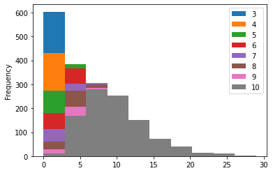

```python
df.plot.hist()
```

- 알수가없다..

`-` bins와 투명도 조절

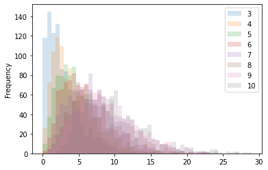

```python
df.plot.hist(bins=50,alpha=0.2)
```

- 조금 나아지긴했으나..

`-` 서브플랏

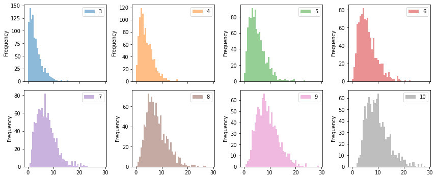

```python
df.plot.hist(bins=50,subplots=True,layout=(2,4),figsize=(12,5),alpha=0.5)
plt.tight_layout()
```

- 많이 더할수록 비대칭성이 완화되고 종모양에 가까워지는것 같다?

`-` kde 플랏

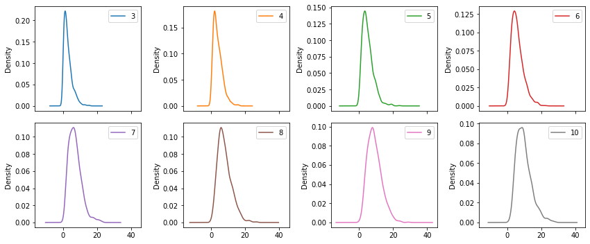

```python
df.plot.kde(subplots=True,layout=(2,4),figsize=(12,5))
plt.tight_layout()
```

`-` bw_method를 조정하면?

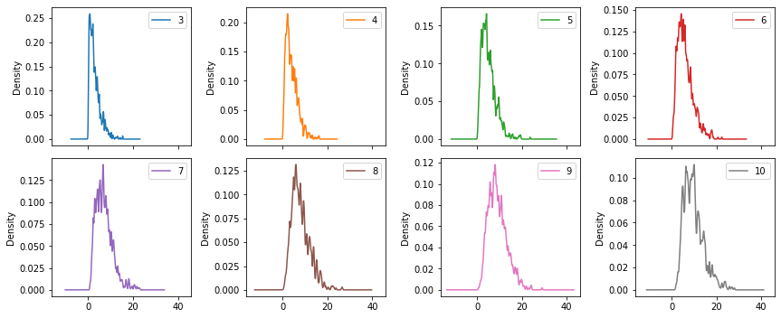

```python
df.plot.kde(subplots=True,layout=(2,4),bw_method=0.05,figsize=(12,5))
plt.tight_layout()
```

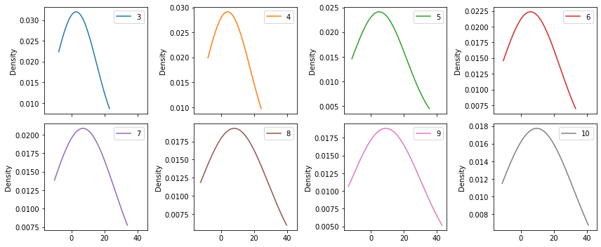

```python
df.plot.kde(subplots=True,bw_method=5,layout=(2,4),figsize=(12,5))
plt.tight_layout()
```

- bw_method를 크게할수록 극단적으로 스무딩한다.

`-` 점선으로 그리고싶다면?

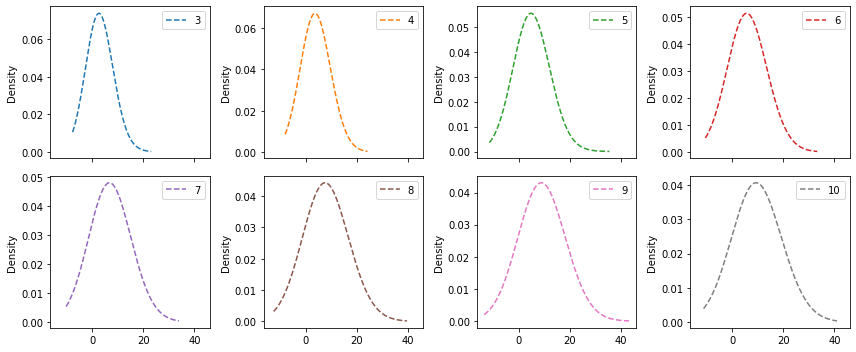

```python
df.plot.density(subplots=True,bw_method=2,layout=(2,4),figsize=(12,5),ls='--')
plt.tight_layout()
```